# Review of the Bioinformatics module of Human Genetics & Genomics

Dennis Hazelett  
June 9th, 2020

### Global overview plot (lecture 1)

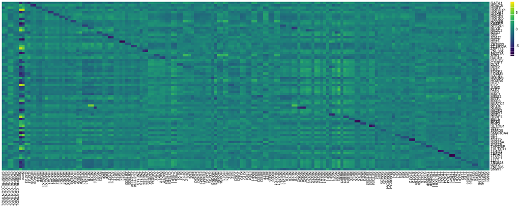

- visualization as an aid for diagnostics
- data selection and curation for GENAVi

### RNA-seq: Workflows (lecture 2)

[figure not shown]

### RNA-seq: Workflows (lecture 2)

Remember and understand:

- what is the purpose of normalization?
- under what circumstances is it relevant to RNA-seq analysis?
- what is the difference between statistical inference and statistical modeling?

### RNA-seq: Workflows (lecture 2)

What are the common normalization methods?

- Counts per million (CPM)
- Trimmed mean of M-values (TMM/edgeR)
- RPKM *vs.* FPKM
- Transcripts per million (TPM - Salmon)

### GENAVi (lecture 2)

Steps:

- visualize
- choose a model
- differential analysis
- PCA (week 2)

### Distributions (lecture 3)

What are the ways that count data can be modeled?

### Distributions (lecture 3)

What are the ways that count data can be modeled?

- binomial vs. negative binomial?

### Distributions (lecture 3)

What are the ways that count data can be modeled?

- binomial vs. negative binomial?
- How does DESeq2 model count data?

### PCA and t-SNE methods (lecture 3)

- What is PCA?

### PCA and t-SNE methods (lecture 3)

- How many dimensions in PC analysis?

### PCA and t-SNE methods (lecture 3)

- How does t-SNE differ?

### Enrichment (lecture 4)

We discussed 3 different models for enrichment calculation

### Enrichment (lecture 4)

We discussed 3 different models for enrichment calculation

- Fisher's exact test
- \( \chi ^ {2} \) (not covered)

### Enrichment (lecture 4)

We discussed 3 different models for enrichment calculation

- Fisher's exact test
- \( \chi ^ {2} \) (not covered)
- Bayesian proportional enrichment

### Enrichment (lecture 4)

We discussed 3 different models for enrichment calculation

- Fisher's exact test
- \( \chi ^ {2} \) (not covered)
- Bayesian proportional enrichment
- Enrichment in a ranked list

### Fisher's exact test (lecture 4)

Key assumptions:

### Fisher's exact test (lecture 4)

How to do it (black and white marbles problem)

- `phyper()`
- `q = q - 1`
- `lower.tail = FALSE`
- `logp = TRUE`

### Fisher's exact test (lecture 4)

What kinds of biological/genomics problems does it apply to?

### Bayesian enrichment w/ two proportions (lecture 4)

Key Assumptions

- foreground probabilities unknown
- background probabilities unknown
- sample available for both
- beta distribution applies ( *i.i.d.* )

### Bayesian enrichment w/ two proportions (lecture 4)

What kinds of biological/genomics problems does it apply to?

### Enrichment in a ranked list (lecture 4)

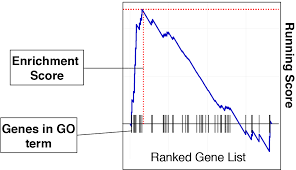

### Enrichment in a ranked list (lecture 4)

- evaluate and interpret a GSEA curve
- know how the p-values are generated

### File Formats (lecture 5)

Identify on sight:

- FASTA
- FASTQ
- GTF
- BED
- VCF

### File Formats (lecture 5)

Be able to answer questions about a FASTQ file similar to what was in the homework!

### File Formats (lecture 5)

What is the purpose of

- SAM, BAM, CRAM
- CIGAR

### Quality control (lecture 6)

Be able to navigate a MultiQC `html` file and interpret in response to questions

### Quality control (lecture 6)

Be able to interpret what pipeline was used by examining a MultiQC `html` file

### Quality control (lecture 6)

Be able to discuss complexity, and backup statements about a sample's complexity by referring to MultiQC graphics

### The Final Exam

- 30 / 100 points
- 6 - 10 questions
- 2 hrs
- open book / open notes
- based on homework

### A final note

Thank you!

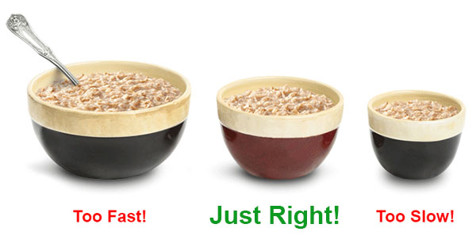

### A (final) final note

Check this out: [Modern Statistics for Modern Biology](http://web.stanford.edu/class/bios221/book/) by **Susan Holmes** and **Wolfgang Huber**

[figure not shown]